# Trabalho MLG

Autor

Eliana Cardoso Gonçalves e Sophia Araujo de Moraes

Data de Publicação

26/08/2024

# 1 Dados da Penn World Table de 2020

Essa relação pode ser expressa pela seguinte equação:

$$Y=β0+β1X1+β2X2+...+βpXp+ε$$

Onde:

- $Y$ é a variável dependente ( PIB Nacional (Y) em dólares PPP de 2014).
- $X1,X2,...,Xp$ são as variáveis independentes ( Força de Trabalho (L)e o Estoque de Capital (K) em dólares PPP de 2014).
- $β1,β2,...,βp$ são os coeficientes de regressão que representam os efeitos das variáveis independentes na variável dependente.
- $ε$ é o termo de erro, que representa a variação não explicada pelo modelo.

Para complementar a análise, é importante entender como os dois modelos — o Modelo Linear Normal e o Modelo Gama Log-Linear — foram utilizados para explorar as relações entre o PIB nacional, a força de trabalho e o estoque de capital. Esses modelos oferecem diferentes abordagens para analisar os dados e podem fornecer insights valiosos sobre os fatores que impulsionam o crescimento econômico:

**Modelo Linear Normal**: O Modelo Linear Normal é uma aplicação clássica da regressão linear múltipla. Neste contexto, assume-se que a relação entre as variáveis independentes (força de trabalho e estoque de capital) e a variável dependente (PIB) é linear. Isso significa que cada incremento em uma variável independente resulta em um aumento ou diminuição constante na variável dependente, dependendo do sinal e do valor dos coeficientes de regressão.

Este modelo é baseado em algumas suposições, como a normalidade dos resíduos, homocedasticidade (ou seja, a variância constante dos resíduos), e a ausência de multicolinearidade entre as variáveis independentes. Quando essas suposições são satisfeitas, o Modelo Linear Normal fornece estimativas consistentes e eficientes dos coeficientes de regressão, permitindo uma compreensão clara de como cada fator contribui para o PIB.

**Modelo Gama Log-Linear**: Por outro lado, o Modelo Gama Log-Linear oferece uma abordagem alternativa, especialmente útil quando os dados não atendem às suposições de normalidade e homocedasticidade do modelo linear. Este modelo é particularmente apropriado para situações onde a variável dependente (PIB) assume valores positivos e pode apresentar uma distribuição assimétrica, o que é comum em dados econômicos.

No Modelo Gama Log-Linear, a transformação logarítmica é aplicada à variável dependente. Isso permite capturar relações não lineares entre o PIB e as variáveis independentes, como a força de trabalho e o estoque de capital. A distribuição Gama, utilizada nesse modelo, é adequada para modelar a variável dependente em casos onde há heterocedasticidade — ou seja, quando a variabilidade dos dados aumenta com o valor previsto.

Essa abordagem é especialmente útil para capturar efeitos multiplicativos, onde as variáveis independentes influenciam a variável dependente de forma proporcional, em vez de aditiva. O Modelo Gama Log-Linear pode, portanto, revelar nuances e complexidades na relação entre os fatores estudados e o crescimento econômico que o modelo linear normal pode não captar.

## 1.1 Modelo Linear Normal

Tabela 1: Tabela Resumo das Variáveis Y, L e K.

|  | K | L | Y |
| --- | --- | --- | --- |
| Mean | 3058761.263 | 54.6094443 | 769941.411 |
| Std.Dev | 8413105.576 | 196.3877082 | 2264112.549 |
| Min | 7345.099 | 0.2993725 | 2569.155 |
| Median | 394840.953 | 11.6562212 | 123419.395 |
| Max | 64118472.000 | 2045.9122435 | 18244220.000 |

Figura 1: Histograma PIB Nacional (Y) em dólares PPP de 2014

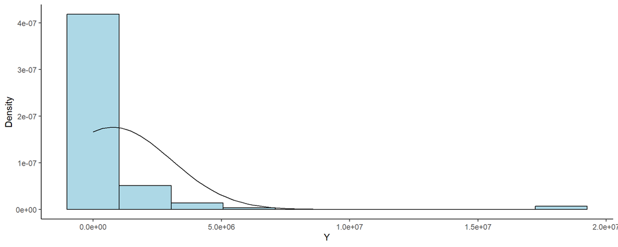

Observando o Figura 1 e Tabela 1 , o valor mínimo do PIB é $2.569, enquanto o valor máximo é significativamente maior, chegando a $18.244.220, indicando uma grande variação no PIB entre os países da amostra.A média do PIB é $769.941, o que é substancialmente maior que a mediana de $123.419, sugerindo que alguns países com PIB muito alto estão puxando a média para cima. A distribuição do PIB é bastante assimétrica, com muitos países tendo PIBs relativamente baixos e poucos países com PIBs muito altos.

Figura 2: Histograma Força de Trabalho (L)

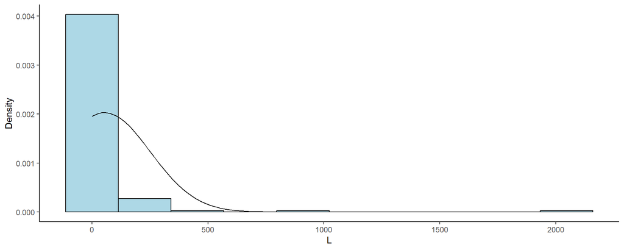

Analisando o Figura 2 e a Tabela 1, a variação da força de trabalho de 0,2994 a 2.045,91 reflete uma grande disparidade na população economicamente ativa entre os países. Com uma média de 54,60 e uma mediana de 11,65, a distribuição mostra-se assimétrica, sugerindo a presença de países com forças de trabalho extremas, seja pela sua grandeza ou pequenez em relação à média da amostrm alguns países com países com a força de trabalho outlier.

Figura 3: Histograma Estoque de Capital (K) em dólares PPP de 2014)

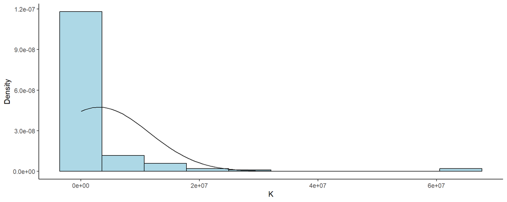

Analisando os valores da Tabela 1 e Figura 3 , observamos que o estoque de capital varia amplamente, de $7.345 a $64.118.472, indicando diferenças significativas no nível de investimento em capital produtivo entre os países.

A média do estoque de capital é $3.058.761, consideravelmente maior que a mediana de $394.841, o que sugere que alguns países têm estoques de capital extremamente altos que estão elevando a média.

### 1.1.1 Resultados

Para garantir a robustez e confiabilidade dos resultados, optamos por realizar uma transformação log-log nas variáveis, considerando que o PIB Nacional (Y) em dólares PPP de 2014, juntamente com as variáveis independentes “força de trabalho” e “estoque de capital”, não apresentam uma distribuição normal. Essa abordagem vai permitir que aos pressupostos do modelo normal sejam atendidos e obter resultados mais consistentes.

Ao aplicar a transformação log-log, estamos ajustando a distribuição das variáveis para se adequarem melhor ao modelo, mitigando quaisquer distorções ou viés que possam surgir devido à falta de normalidade. Isso nos permite realizar inferências estatísticas mais confiáveis e interpretar os efeitos das variáveis independentes sobre o PIB Nacional de forma mais precisa.

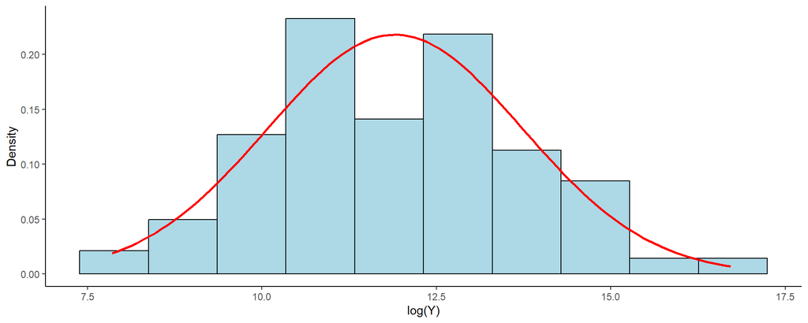

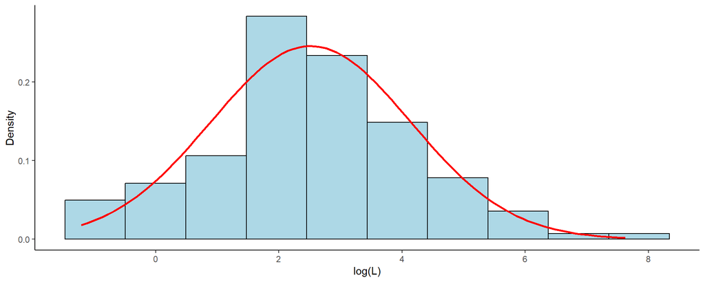

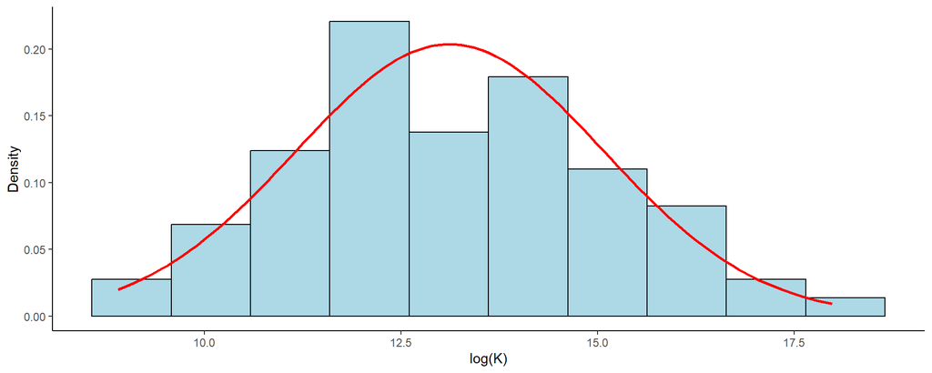

Essa estratégia de transformação aumenta a robustez da análise, pois reduz a influência de valores extremos e torna os resultados menos sensíveis a distribuições não normais. Portanto, podemos ter maior confiança nas conclusões derivadas do modelo, garantindo uma abordagem metodológica sólida e resultados mais confiáveis para tomada de decisão.

A análise macroeconômica é fundamental para entender o desenvolvimento econômico e social dos países. No contexto da contabilidade nacional, variáveis como o Produto Interno Bruto (PIB), a força de trabalho e o estoque de capital são essenciais para avaliar a produtividade e o crescimento econômico. Este estudo utiliza dados da Penn World Table de 2020 para investigar a relação entre essas variáveis.

O PIB nacional (Y), medido em dólares PPC de 2014, é uma medida abrangente da atividade econômica de um país. A força de trabalho (L) representa o total de pessoas empregadas ou em busca de emprego, refletindo a capacidade produtiva humana. O estoque de capital (K), também medido em dólares PPC de 2014, indica o valor total dos ativos produtivos de um país, como máquinas, edifícios e infraestrutura.

Ao analisar essas variáveis, o objetivo é fornecer insights sobre as políticas econômicas que podem fomentar o crescimento e a produtividade. Esta investigação pode ajudar formuladores de políticas, economistas e pesquisadores a identificar áreas-chave para intervenção e investimento, promovendo um desenvolvimento econômico sustentável e inclusivo.

Tabela 2: Ajuste do Modelo de Regressão Log-Normal

|  | Estimação | Pvalor | sig |
| --- | --- | --- | --- |
| (Intercept) | 1.8881930 | 0 | <0.001*** |
| log(L) | 0.2940893 | 0 | <0.001*** |
| log(K) | 0.7072816 | 0 | <0.001*** |

Todos os p-valores associados aos coeficientes são muito pequenos (<0.001), o que significa que podemos rejeitar a hipótese nula para todos os coeficientes, ao nível de 5% de confiança. Isso indica que tanto a força de trabalho quanto o estoque de capital têm efeitos significativos no PIB, conforme medido pelo logaritmo.

Além disso, o modelo tem um R-quadrado ajustado de aproximadamente 0,96, o que significa que aproximadamente 95,92% da variabilidade no logaritmo do PIB pode ser explicada pelas variáveis independentes incluídas no modelo.

Esses resultados sugerem que tanto a força de trabalho quanto o estoque de capital têm um impacto significativo no PIB, conforme medido pelo logaritmo.

- **Hipótese Nula** $(H_0)$: $\alpha + \beta = 1$ A soma dos coeficientes é igual a 1, sugerindo retornos constantes à escala.
- **Hipótese Alternativa** $(H_1)$: $\alpha + \beta \neq 1$ A soma dos coeficientes não é igual a 1, sugerindo que não há retornos constantes à escala.

Tabela 3: Teste

| Estatística | Valor |
| --- | --- |
| Estimativa de alpha | 0.2941 |
| Estimativa de beta | 0.7073 |
| Soma de alpha e beta | 1.0014 |
| Estatística t | 0.0721 |
| Valor-p | 0.9427 |

Na Tabela 3, com teste da Teste $𝐻0 : 𝛼 + 𝛽 = 1$ contra $𝐻1 : 𝛼 + 𝛽 ≠ 1$, obtivemos um p-valor de aproximadamente 0,943. Não rejeitamos a hipótese nula $H_0$ ao nível de 5% de significância. Isso indica que os dados não fornecem evidências suficientes para concluir que a soma de $\alpha$ e $\beta$ é diferente de 1. Em outras palavras, a suposição de retornos constantes à escala $\alpha + \beta = 1$ é razoável para o ano analisado. Isso sugere que, com base nos dados, um aumento proporcional igual na força de trabalho (L) e no capital (K) resulta em um aumento proporcional na produção (Y), confirmando a hipótese de retornos constantes à escala na função de produção Cobb-Douglas.

### 1.1.2 Análise dos Resíduos

Figura 4: Grafico de Análise de resíduos

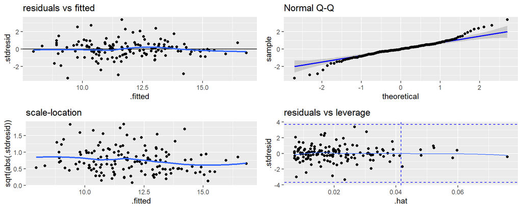

Resultados dos Testes de Resíduos

| Teste | Estatística | p.valor |
| --- | --- | --- |
| Shapiro-Wilk Normality Test | W = 0.96 | 0.0003379 |
| Non-constant Variance Score Test | Chisquare = 5.338458 | 0.0208600 |
| Durbin-Watson Test for Autocorrelated Errors | D-W Statistic = 2.133801 | 0.4200000 |

Com base na análise da tabela Figura 4, podemos concluir o seguinte sobre o ajuste do modelo de regressão:

**Normalidade:** - Embora o teste de Shapiro-Wilk sugira que os resíduos não sigam uma distribuição normal, desconsiderando caudas pesadas tanto nos extremos inferiores quanto nos superiores, podemos aproximar que os resíduos estão próximos de uma distribuição normal.

**Independência dos Resíduos:** - Tanto o teste de Durbin-Watson quanto a inspeção do gráfico de resíduos versus valores ajustados na tabela Figura 4 não fornecem evidências significativas para rejeitar a hipótese nula de ausência de autocorrelação positiva ou negativa nos resíduos. Assim, parece que os resíduos são independentes entre si.

**Linearidade:** - Não há um padrão claro nos resíduos plotados em relação aos valores ajustados, indicando linearidade entre as variáveis independentes e dependentes.

## 1.2 Modelo Gama Log-Linear

### 1.2.1 Resultados

Utilizamos o mesmo banco de dados do Modelo de Log-Normal.Por meio da tabela abaixo é possível verificar como foi o ajuste das variáveis ao modelo de gama log-linear:

Tabela 4: Modelo Gamma Log-linear

|  | Estimacao | ErroPadrao | Pvalor | sig |
| --- | --- | --- | --- | --- |
| (Intercept) | 1.6175 | 0.0286 | 0 | <0.001*** |
| log(L) | 0.0237 | 0.0032 | 0 | <0.001*** |
| log(K) | 0.0601 | 0.0026 | 0 | <0.001*** |

O intercepto estimado de 1.61754583 (Tabela 4) representa o logaritmo da produção quando tanto o trabalho (L) quanto o capital (K) são iguais a 1. Com um p-valor extremamente pequeno, o intercepto é estatisticamente significativo, indicando que ele desempenha um papel importante na modelagem da variável dependente 𝑌𝑖, ao nível de 5% de significância.

O coeficiente para log(L) é 0.02371, indicando que um aumento de 1% na força de trabalho (L) leva a um aumento de aproximadamente 0.024% na produção, mantendo o capital constante. O p-valor extremamente pequeno indica que este coeficiente é altamente significativo, o que valida a importância da força de trabalho na determinação da produção no modelo.

O coeficiente para log(K) é 0.06012, sugerindo que um aumento de 1% no capital (K) resulta em um aumento de aproximadamente 0.060% na produção, mantendo a força de trabalho constante. Com um p-valor extremamente baixo, esse coeficiente é altamente significativo, demonstrando que o capital tem uma influência importante e estatisticamente significativa na produção.

O parâmetro de dispersão estimado é 0.00135, o que indica que há uma baixa variabilidade dos dados em torno da média ajustada pelo modelo. Isso sugere que o modelo gamma log-linear está capturando bem a dispersão dos dados, com pouca heterogeneidade residual não explicada pelo modelo.

Tabela 5: Teste

| Descrição | Valor |
| --- | --- |
| Soma de alpha e beta | 0.0838 |
| Erro padrão | 0.0019 |
| Estatística t | -483.1625 |
| Valor-p | 7.4303651624535e-229 |
| Decisão | Rejeitamos H0 |

Decisão sobre Teste $𝐻0 : 𝛼 + 𝛽 = 1$ contra $𝐻1 : 𝛼 + 𝛽 ≠ 1$: (Tabela 5) Como o valor-p é extremamente pequeno, rejeitamos a hipótese nula $H_0$ indicando que a soma de $\alpha$ e $\beta$ é significativamente diferente de 1. Isso significa que a hipótese de retornos constantes à escala não é válida para os dados analisados.

Retornos constantes à escala implicam que, se ambos os insumos (L e K) aumentarem na mesma proporção, a produção $Y_i$ também aumentará na mesma proporção. No entanto, dado que a soma de $\alpha$ e $\beta$ é significativamente diferente de 1, isso sugere que os retornos à escala não são constantes para este modelo. Dependendo do valor específico da soma $(\alpha + \beta < 1$ ou $\alpha + \beta > 1)$, os retornos à escala podem ser decrescentes ou crescentes, respectivamente.

Assim, a soma de $\alpha$ e $\beta$ é 0.08383678, o que está longe de 1, indicando retornos decrescentes à escala. Isso significa que aumentar proporcionalmente a força de trabalho e o capital levará a um aumento menos que proporcional na produção. Em outras palavras, conforme mais insumos são adicionados, a produtividade marginal desses insumos diminui, levando a um crescimento menos eficiente da produção.

### 1.2.2 Análise dos Resíduos

Tabela 6: Gráfico de Análise de resíduos

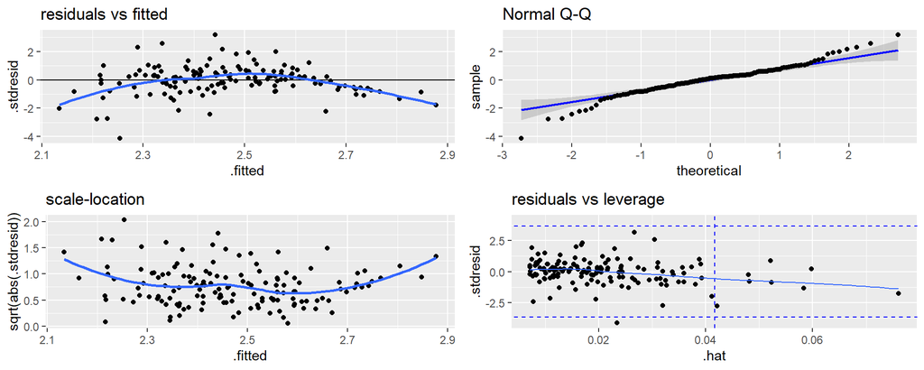

Resultados dos Testes de Breusch-Pagan e Durbin-Watson

| Teste | Estatística | Valor.p | Decisão |
| --- | --- | --- | --- |
| Breusch-Pagan | 2.6679 | 0.2634 | Não rejeitamos H0 |
| Durbin-Watson | 2.1338 | 0.7801 | Não rejeitamos H0 |

Com base na análise dos resíduos, incluindo os testes de Breusch-Pagan e Durbin-Watson, podemos concluir o seguinte sobre o ajuste do modelo de regressão:

**Independência dos Resíduos:** - Tanto o teste de Durbin-Watson quanto a inspeção do gráfico de resíduos versus valores ajustados na tabela Tabela 6 não fornecem evidências significativas para rejeitar a hipótese nula de ausência de autocorrelação positiva ou negativa nos resíduos. Assim, parece que os resíduos são independentes entre si, o que é uma boa indicação de que o modelo está adequadamente ajustado quanto a essa suposição.

**Linearidade:** - Há um padrão claro nos resíduos plotados em relação aos valores ajustados, indicando não linearidade entre as variáveis independentes e dependentes.

## 1.3 Comparação dos Modelos: Gamma Log-Linear vs. Modelo Normal

Comparação dos Modelos Gamma Log-Linear e Normal

| Critério | Modelo.Gamma.Log.Linear | Modelo.Normal |
| --- | --- | --- |
| Log-Likelihood | -83.07791 | -59.39108 |
| AIC | 174.15580 | 126.78220 |
| BIC | 186.03510 | 138.66140 |

Log-Likelihood (Log-Verossimilhança) - **Modelo Gamma Log-Linear**: -83.07791 - **Modelo Normal**: -59.39108

O valor de log-likelihood mais alto (menos negativo) indica um melhor ajuste do modelo aos dados. O modelo normal tem um valor de log-likelihood mais alto, sugerindo que se ajusta melhor aos dados em comparação com o modelo Gamma log-linear.

Critério de Informação de Akaike (AIC) - **Modelo Gamma Log-Linear**: 174.1558 - **Modelo Normal**: 126.7822

Valores menores de AIC indicam um modelo mais eficiente em termos de ajuste aos dados com penalização pela complexidade. O modelo normal apresenta um AIC significativamente menor, indicando que é mais eficiente e se ajusta melhor aos dados do que o modelo Gamma log-linear.

Critério de Informação de Bayes (BIC) - **Modelo Gamma Log-Linear**: 186.0351 - **Modelo Normal**: 138.6614

O BIC também penaliza a complexidade do modelo e valores menores indicam um ajuste melhor com menor penalização por complexidade. Novamente, o modelo normal apresenta um BIC significativamente menor, reforçando que é mais adequado para os dados em comparação ao modelo Gamma log-linear.

Com base nos critérios de log-likelihood, AIC e BIC, o **modelo normal** é a melhor escolha. Ele não só se ajusta melhor aos dados (conforme indicado pelo log-likelihood), mas também é mais eficiente e simples em termos de complexidade (conforme indicado pelos valores de AIC e BIC).

Portanto, o modelo normal é preferível ao modelo Gamma log-linear para a análise dos seus dados, oferecendo um melhor equilíbrio entre ajuste e complexidade.

# 2 Dados Kaggle - análise de clssificação de crédito

## 2.1 Modelo Logistico

Para este estudo, utilizamos uma base de dados obtida do Kaggle, que contém informações detalhadas sobre clientes de uma instituição financeira. O objetivo principal é desenvolver um modelo de machine learning para classificar o crédito dos clientes em diferentes faixas de risco, otimizando os processos de decisão e reduzindo esforços manuais. A base de dados inclui 100.000 observações e 28 variáveis, como idade, ocupação, renda anual, número de contas bancárias e histórico de pagamentos.

A análise foca na construção e avaliação de um modelo de **regressão logística**, adequado para situações em que a variável dependente é categórica, como a classificação de crédito (“Poor” e “Good”). A **regressão logística** estima a probabilidade de um evento binário ocorrer e classifica as observações em categorias. A equação do modelo logístico é expressa como:

$$log(p / (1 - p)) = β0 + β1 * X_1 + β2 * X_2 + ... + βp * X_p$$

Onde:

Como parte da análise, será explorado o ajuste do modelo, avaliando os resíduos para verificar a adequação do modelo.

Resumo Descritivo das Variáveis

| Variável | Estatística |
| --- | --- |
| Credit_Score | Good: 12192, Poor: 19884 |
| Credit_Mix | Good: 13518, Standard: 8509, Bad: 10049 |
| Outstanding_Debt | Min.: 0.23, 1st Qu.: 702.54, Median: 1360.45, Mean: 1593.26, 3rd Qu.: 2258.30, Max.: 4998.07 |
| Payment_of_Min_Amount | No: 14432, Yes: 17644 |
| Changed_Credit_Limit | Min.: -6.480, 1st Qu.: 4.570, Median: 8.560, Mean: 9.573, 3rd Qu.: 13.130, Max.: 35.820 |

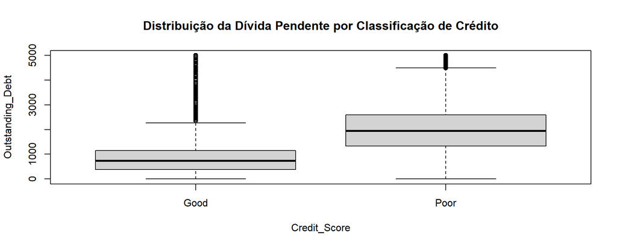

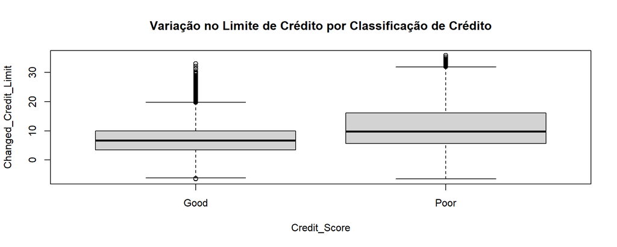

Resultados dos Testes Qui-Quadrado

| Teste | Estatística | Graus.de.Liberdade | Valor.p | Decisão |
| --- | --- | --- | --- | --- |
| Credit_Mix vs Credit_Score | 14606 | 2 | < 2.2e-16 | Rejeitamos H0 |
| Payment_of_Min_Amount vs Credit_Score | 14578 | 1 | < 2.2e-16 | Rejeitamos H0 |

A análise associativa preliminar entre as variáveis do estudo revela insights importantes sobre os padrões de crédito dos clientes. Através dos boxplots, observa-se que a dívida pendente (Outstanding_Debt) tende a ser maior entre os clientes com uma classificação de crédito “Poor” em comparação com aqueles classificados como “Good”. Isso sugere que clientes com maiores dívidas são mais propensos a terem uma classificação de crédito inferior. Além disso, as mudanças no limite de crédito (Changed_Credit_Limit) também variam significativamente entre as classificações de crédito, com clientes de crédito “Poor” exibindo maior variação, o que pode indicar instabilidade financeira.

### 2.1.1 Modelo logístico ajustado

Além disso, para a construção do modelo foram utilizadas as seguintes variáveis:

Resultados do Modelo de Regressão Logística

| Variável | Estimacao | ErroPadrao | Pvalor |
| --- | --- | --- | --- |
| (Intercept) | -1.4850888 | 0.0361200 | < 0.05 |
| Credit_MixStandard | 1.0098831 | 0.0701266 | < 0.05 |
| Credit_MixBad | 2.3447565 | 0.1036433 | < 0.05 |
| Outstanding_Debt | 0.0006567 | 0.0000294 | < 0.05 |
| Payment_of_Min_AmountYes | 1.4233394 | 0.0804651 | < 0.05 |
| Changed_Credit_Limit | -0.0238181 | 0.0036734 | < 0.05 |

Os coeficientes do modelo são significativos, com valores de p inferiores a 0,05 para todas as variáveis, indicando que elas têm uma contribuição estatisticamente significativa na previsão da classificação de crédito.

O modelo apresenta um desvio nulo de 42604 e um desvio residual de 24833. A redução no desvio residual em relação ao desvio nulo indica que o modelo com as variáveis independentes tem um ajuste significativamente melhor do que o modelo nulo. Em outras palavras, o modelo ajustado reduz a discrepância entre os valores previstos e os observados de forma significativa.

Quanto ao AIC, vale salientar que O AIC é uma métrica que ajuda a avaliar a qualidade do ajuste do modelo, levando em consideração tanto a complexidade quanto a adequação ao conjunto de dados. A principal função do AIC é penalizar modelos mais complexos, que possuem um maior número de parâmetros, para evitar o ajuste excessivo aos dados (overfitting).No caso, o AIC obtido foi de 24845. Para determinar se este valor indica um bom ajuste do modelo, é necessário compará-lo com o AIC de outros modelos que você pode ter testado.

Para o modelo ajustado foi calculado também a razão de chances:

Razões de Chances (Odds Ratios) do Modelo de Regressão Logística

|  | Odds_Ratio |
| --- | --- |
| (Intercept) | 0.226 |
| Credit_MixStandard | 2.745 |
| Credit_MixBad | 10.431 |
| Outstanding_Debt | 1.001 |
| Payment_of_Min_AmountYes | 4.151 |
| Changed_Credit_Limit | 0.976 |

Tentamos ajustar o modelo logistico, re-escalando Outstanding Debt:

Resultados do Modelo de Regressão Logística

| Variável | Estimacao | ErroPadrao | Pvalor |
| --- | --- | --- | --- |
| (Intercept) | -1.4850888 | 0.0361200 | < 0.05 |
| Credit_MixStandard | 1.0098831 | 0.0701266 | < 0.05 |
| Credit_MixBad | 2.3447565 | 0.1036433 | < 0.05 |
| Outstanding_Debt_scaled | 0.0656720 | 0.0029353 | < 0.05 |
| Payment_of_Min_AmountYes | 1.4233394 | 0.0804651 | < 0.05 |
| Changed_Credit_Limit | -0.0238181 | 0.0036734 | < 0.05 |

Visando verificar se é possível melhorar o modelo logístico ajustado, a variável Outstanding_Debt foi recalibrada. No modelo anterior, o coeficiente para Outstanding_Debt era muito pequeno (6.567e-04), enquanto no modelo ajustado com a variável escalada (Outstanding_Debt_scaled), a estimativa do coeficiente foi significativamente maior (0.065672), indicando um efeito mais expressivo da variável escalada. No entanto, apesar de a escalagem ter melhorado a interpretação dos coeficientes, os desvios nulo e residual, assim como o AIC, permaneceram inalterados (o AIC é 24845 para ambos os modelos). Isso sugere que, embora a escalagem tenha proporcionado coeficientes mais interpretáveis, ela não resultou em uma melhoria no ajuste global do modelo.

### 2.1.2 Análise dos Resíduos

A análise dos resíduos é crucial para avaliar se o modelo logístico está bem ajustado. Resíduos bem comportados, ou seja, sem padrões claros e distribuídos de forma aleatória, indicam que o modelo é adequado. Se houver padrões nos resíduos, isso pode sugerir que o modelo não está capturando toda a variabilidade dos dados, podendo haver variáveis importantes faltantes ou problemas de especificação do modelo

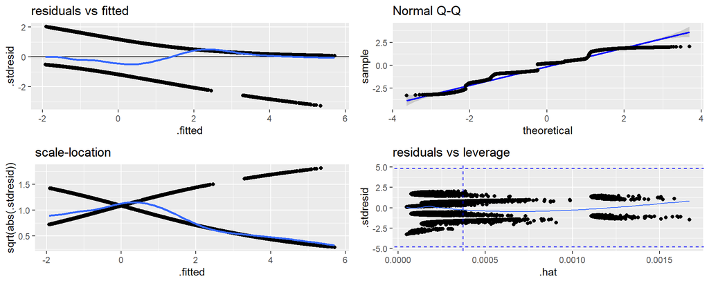

Resultados dos Testes Breusch-Pagan e Durbin-Watson

| Teste | Estatistica | Graus_de_Liberdade | P_valor |
| --- | --- | --- | --- |
| Breusch-Pagan | BP = 3931.9 | df = 5 | p-value < 2.2e-16 |
| Durbin-Watson | DW = 0.65232 | NA | p-value < 2.2e-16 |

Com base nos resultados obtidos via Teste de Breusch-Pagan e Teste de Durbin-Watson, podemos concluir o seguinte sobre o ajuste do modelo de regressão logística:

**Homocedasticidade:** - O Teste de Breusch-Pagan resultou em um valor de BP = 3931.9 com um valor-p < 2.2e-16. Esse valor-p extremamente baixo indica que rejeitamos a hipótese nula de homocedasticidade. Em outras palavras, há evidências significativas de heterocedasticidade nos resíduos do modelo. Isso sugere que a variância dos resíduos não é constante ao longo dos valores preditores, o que pode indicar que o modelo não está capturando completamente a variabilidade dos dados.

**Independência dos Resíduos:** - O Teste de Durbin-Watson forneceu um valor de DW = 0.65232 com um valor-p < 2.2e-16, indicando uma forte presença de autocorrelação positiva nos resíduos. Isso sugere que os resíduos não são independentes entre si, o que pode indicar que o modelo não está capturando todos os padrões nos dados ou que há uma estrutura de dependência não modelada.

A inspeção do gráfico de resíduos versus valores ajustados também pode revelar padrões adicionais que confirmem a presença de autocorrelação.

**Linearidade:** - Há um padrão claro nos resíduos plotados em relação aos valores ajustados, indicando não linearidade entre as variáveis independentes e dependentes.

Desse modo, os resultados sugerem que o modelo enfrenta problemas de heterocedasticidade e autocorrelação positiva dos resíduos, o que pode impactar a precisão e a validade do modelo.

### 2.1.3 Análise do VIF (Variance Inflation Factor)

O VIF (Fator de Inflação da Variância) é uma medida importante para identificar a presença de multicolinearidade entre os preditores em um modelo de regressão. Valores elevados de VIF sugerem que um preditor está altamente correlacionado com outros preditores no modelo, o que pode inflacionar os erros padrão das estimativas dos coeficientes e dificultar a identificação da real significância das variáveis.

VIF dos Preditores

| Preditor | GVIF | Df | Ajuste.do.GVIF |
| --- | --- | --- | --- |
| Credit_Mix | 5.405144 | 2 | 1.524761 |
| Outstanding_Debt | 1.626080 | 1 | 1.275178 |
| Payment_of_Min_Amount | 5.496045 | 1 | 2.344365 |
| Changed_Credit_Limit | 1.558789 | 1 | 1.248515 |

Erros Padrão dos Coeficientes

| Coeficiente | Erro_Padrão |
| --- | --- |
| Intercept | 0.0361200 |
| Credit_MixStandard | 0.0701266 |
| Credit_MixBad | 0.1036433 |
| Outstanding_Debt | 0.0000294 |
| Payment_of_Min_AmountYes | 0.0804651 |
| Changed_Credit_Limit | 0.0036734 |

No modelo analisado, observamos que as variáveis Credit_Mix e Payment_of_Min_Amount têm VIFs relativamente altos, com valores de 5.41 e 5.50, respectivamente. Esses valores indicam uma alta colinearidade com outras variáveis do modelo. Isso é corroborado pelos erros padrão dos coeficientes: Credit_MixStandard e Credit_MixBad apresentam erros padrão elevados, especialmente Credit_MixBad com um erro padrão de 0.1036, o que sugere que as estimativas dos coeficientes para estas variáveis são menos precisas e podem ser afetadas pela multicolinearidade.

Em contraste, Outstanding_Debt e Changed_Credit_Limit têm VIFs baixos, de 1.63 e 1.56, respectivamente. Isso sugere que estas variáveis têm baixa colinearidade com outras variáveis do modelo. O erro padrão para Outstanding_Debt é extremamente pequeno (aproximadamente 0.0000), indicando uma estimativa muito precisa para o coeficiente desta variável. Da mesma forma, Changed_Credit_Limit tem um erro padrão muito pequeno (0.0037), o que também sugere uma estimativa precisa para o coeficiente desta variável.

Por outro lado, o erro padrão para Payment_of_Min_AmountYes é relativamente grande (0.0805), o que pode refletir a alta multicolinearidade observada pelo VIF elevado para Payment_of_Min_Amount. Isso indica que a estimativa do coeficiente para esta variável pode ser menos confiável.

Em resumo, a alta multicolinearidade identificada para Credit_Mix e Payment_of_Min_Amount está associada a erros padrão mais altos para essas variáveis, o que sugere que as estimativas dos coeficientes podem ser imprecisas. Em contraste, variáveis com VIFs baixos como Outstanding_Debt e Changed_Credit_Limit apresentam erros padrão menores e estimativas mais confiáveis. Considerar a remoção ou ajuste das variáveis com alta colinearidade pode melhorar a precisão e robustez do modelo.